# Indian Railways Income Analysis

Arjuna Rao C

October 22, 2015

## Executive Summary

Indian Railways is an Indian state-owned enterprise. It is one of the world’s largest railway networks comprising 115,000 km of track over a route of 65,808 km and 7,112 stations. In 2014-15, it carried 8.397 billion passengers annually or more than 23 million passengers a day and 1058.81 million tons of freight in the year. Some Indian Railway data are available from Indian Governement’s Open Data platform. The passenger and goods train traffic data and Income data are used to investigate the contribution of each type of traffic to the income. A Shiny app is developed for predicting the income based on daily average train traffic(Passenger/Goods).

## Introduction

Indian Railways (“Indian Railways - Wikipedia, the Free Encyclopedia” 2015) is an Indian state-owned enterprise. It is one of the world’s largest railway networks comprising 115,000 km of track over a route of 65,808 km and 7,112 stations. In 2014-15, it carried 8.397 billion passengers annually or more than 23 million passengers a day and 1058.81 million tons of freight in the year. Traffic and financial data are available from Indian government’s open data website.(“Average Number of Trains Run Daily” 2015) (“Financial Position of Indian Railways” 2015)

## Data

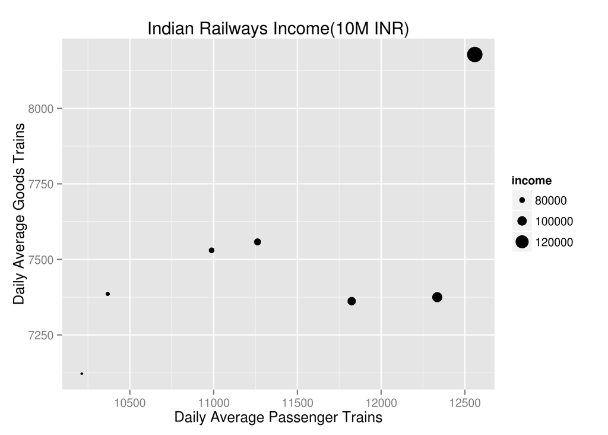

[output not shown]

## Model

A simple linear regression model is fit to the data. The fit quality is acceptable as can be seen from the R^2 parameter and F statistic. The model shows that one daily goods train generates 60% more income than one daily passenger train.

```r
library(knitcitations)
irfa<-read.csv("../data/Indian rail traffic net revenues.csv")
fit1<-lm(income~psgr_trains+goods_trains,data=irfa)
summary(fit1)
```

```
##
## Call:
## lm(formula = income ~ psgr_trains + goods_trains, data = irfa)
##
## Residuals:
##       1       2       3       4       5       6       7
##  3026.5  1950.5 -4713.4 -3159.9   105.0   232.8  2558.5
##
## Coefficients:
##                Estimate Std. Error t value Pr(>|t|)
## (Intercept)  -3.168e+05  3.362e+04  -9.422 0.000707 ***
## psgr_trains   1.740e+01  2.075e+00   8.385 0.001107 **
## goods_trains  2.791e+01  5.764e+00   4.842 0.008388 **
## ---
## Signif. codes:  0 '***' 0.001 '**' 0.01 '*' 0.05 '.' 0.1 ' ' 1
##
## Residual standard error: 3598 on 4 degrees of freedom
## Multiple R-squared:  0.9839, Adjusted R-squared:  0.9758
## F-statistic: 122.1 on 2 and 4 DF,  p-value: 0.0002595
```

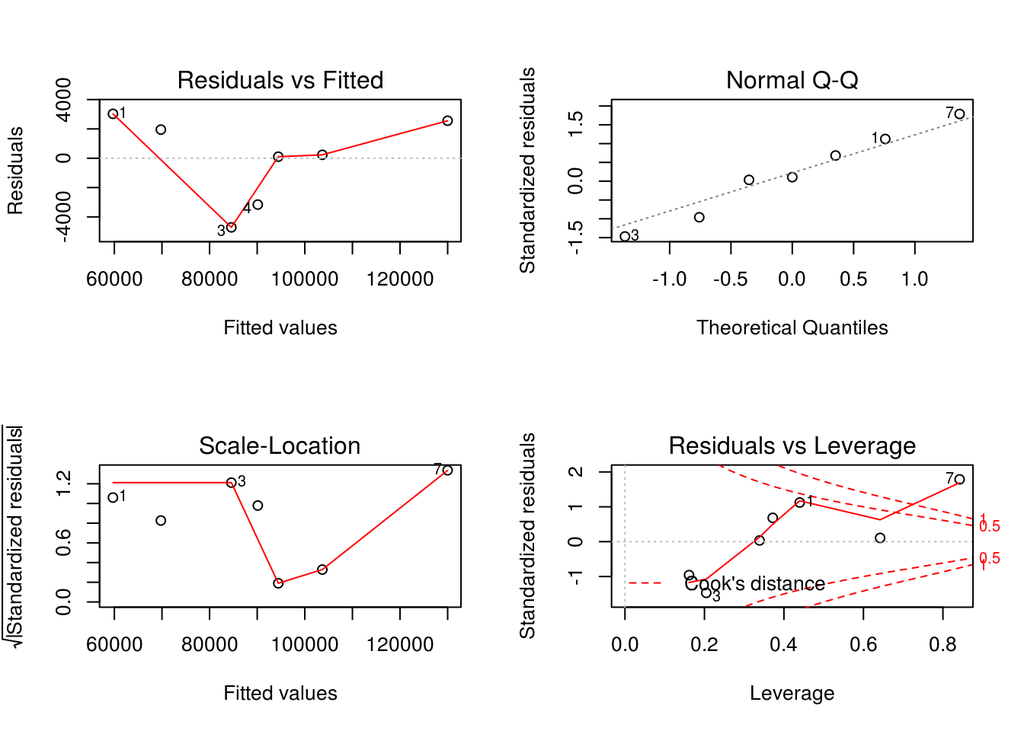

```r
par(mfrow=c(2,2))
plot(fit1)
```

## Shiny Application

A Shiny app called [“IndianRailways”](https://arjunaraoc.shinyapps.io/IndianRailways) is developed to help predict the income for a given daily average passenger and goods train traffic. The UI is shown below.

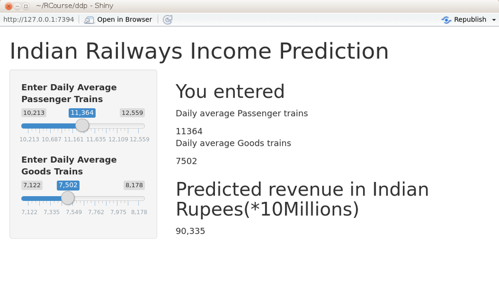

## Conclusion

The passenger and goods train traffic data and Income data are used to investigate the contribution of each type of traffic to the Indian Railways income. The model shows that one daily goods train generates 60% more income than one daily passenger train. A Shiny app is developed for predicting the income based on daily average train traffic(Passenger/Goods).

References

“Average Number of Trains Run Daily.” 2015. *Open Government Data (OGD) Platform India*. https://data.gov.in/catalog/average-number-trains-run-daily. https://data.gov.in/catalog/average-number-trains-run-daily.

“Financial Position of Indian Railways.” 2015. *Open Government Data (OGD) Platform India*. https://data.gov.in/catalog/financial-position-indian-railways. https://data.gov.in/catalog/financial-position-indian-railways.

“Indian Railways - Wikipedia, the Free Encyclopedia.” 2015. *Wikipedia*. https://en.wikipedia.org/wiki/Indian_Railways. https://en.wikipedia.org/wiki/Indian_Railways.